# Binding and Joining Data in R

March 24, 2022 @ 11:30 AM

## Before We Begin…

These slides are not meant to be standalone information, but rather a guide for hands-on lecture. Be prepared to take notes to flesh out the contents.

I recommend that you create an R Markdown document where you can include information and code from the slides as well as your own additional notes and explorations.

These slides were produced using R Markdown. See “[4.1 ioslides presentation](https://bookdown.org/yihui/rmarkdown/ioslides-presentation.html)” in [*R Markdown: The Definitive Guide*](https://bookdown.org/yihui/rmarkdown/).

## Basic Binding Functions

Appends rows or columns to an existing data frame or tibble.

- `rbind()` and `cbind()` — base `R` functions
- `bind_rows()` and `bind_cols()` — dplyr versions ([see help](https://dplyr.tidyverse.org/reference/bind.html))

When using `bind_rows()`, columns are matched by name. Any missing columns will be filled with `NA`.

When using `bind_cols()`, rows are matched by position, so the data frames must have the same number of rows in order.

To match rows by one or more values, use a [mutating join](https://dplyr.tidyverse.org/reference/mutate-joins.html).

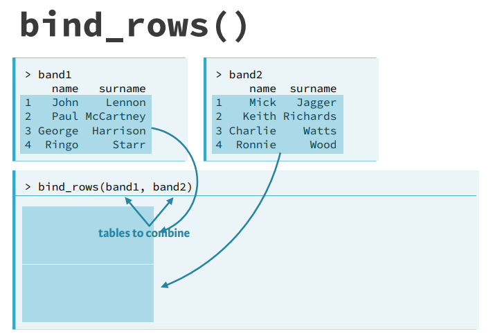

The columns need to match / align properly for base `R` binding.

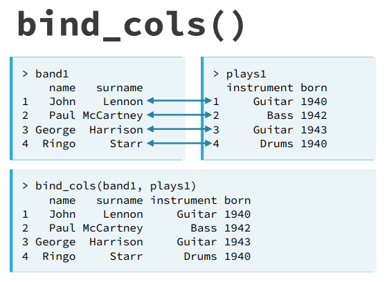

Notice that the cases must be ordered properly before binding. There is no matching `key` like we see in dplyr’s join functions.

## Merging Data

Combine dataframes or tibbles in ways more complicated than sinple row or column binding.

- `merge()` — base `R`, superseded by the dplyr join functions

Merge two data frames by common columns or row names, or do other versions of database join operations.

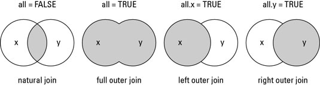

How do these align with dplyr’s join functions?

## Mutating Joins

[Mutating joins](https://dplyr.tidyverse.org/reference/mutate-joins.html) *combine* variables from two data frames / tibbles. Since they **add** variables, they act like a `mutate()` statement. In all cases you get all columns in both sets.

- `inner_join(x, y, by = )`

returns all rows from x where there are matching values in y

- `left_join(x, y, by = )`
- `right_join(x, y, by = )`

returns all rows from one of the datasets, left (x) or right (y)

- `full_join(x, y, by = )`

returns all rows from both datasets (may get many `NA` values)

## Filtering Joins

[Filtering joins](https://dplyr.tidyverse.org/reference/filter-joins.html) keep cases from the left-hand data frame / tibble based information in the right-hand dataset. Thus, the join acts like `filter()` on the left-hand dataset.

- `semi-join(x, y, by = )`

returns all rows from x where there are matching values in y

- `anti-join(x, y, by = )`

returns all rows from x where there are *not* matching values in y

None of the columns in the right-hand data frame / tibble will be added to the left-hand dataset.